.

.

.

# Conda instructions for cloud

# Steps

## *1. Create your own directory in the shared environment:*

You should enter in your "home" directory. To create your shared directory on the cloud (and have more than 10G of space), you need to create a new directory in the /efs directory. First, navigate to the /efs folder (gray folder directly under the search window at the upper left).

Once you're in /efs, click the icon at the upper left that is a folder with a + sign, then give it your user name.

Refresh the window and your name should now appear in the directory list.

[figure not shown]

## *Accessing the Terminal*

[figure not shown]

[figure not shown]

To access the terminal, click on the blue + at the top left. If the you don't see it then click on the first folder (it has the yellow box around it in the image above), this will display the file browser options and now you should be able to see it.  
This will open a new launcher, At the bottom under other select terminal.

## *2. Make sure you’re at home (just in case you were doing something before that)*

```
cd  ~
```

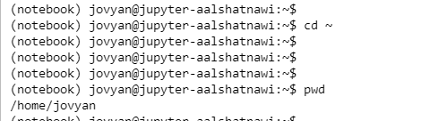

## *3.Make your environment.yml file. Either add an environment.yml file to your home directory, or make a copy of the one from the /Tutorials/efs and put it in your home directory.*

- cp efs/Tutorials/test_environment.yml ~/environment.yml

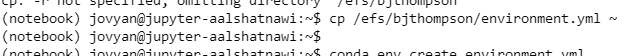

## 4. Edit the environment.yml file by clicking on the environment file name at left MAKE SURE YOU ARE EDITING THE ONE IN YOUR DIRECTORY AND NOT TUTORIALS! The directory name at left should say /efs/Yourname and not /efs/Tutorials. Change the name of the project, and add any python packages you will need (the common ones are already listed).

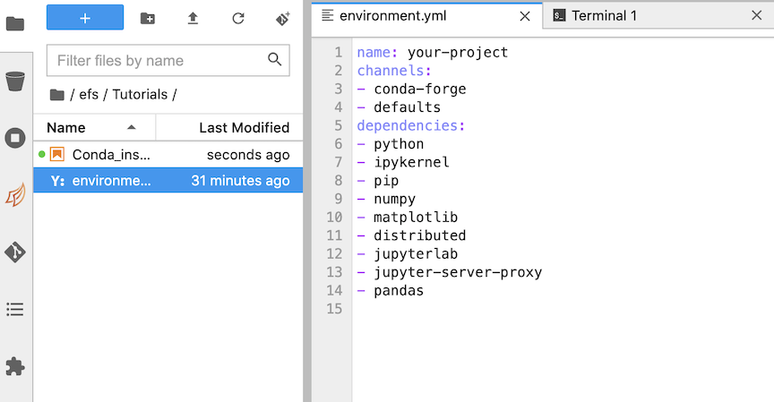

## *5. Create the conda environment*

Go to the Terminal tab that you created and type the text below.

```
conda env create -f environment.yml
```

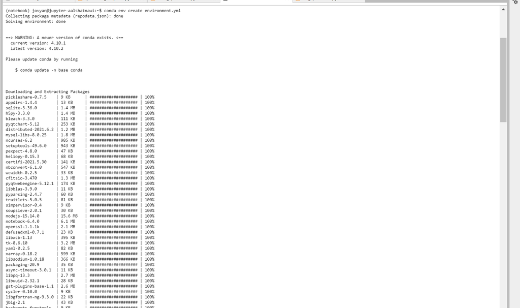

## *6. Then activate the environment. Use the name of the environment at the top of the yml file after name:*

```
conda activate your-project
```

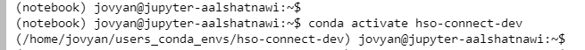

## *7. Check to see if the python environment is set up properly. Type the following:*

[output not shown]

## *8. If successful, restart the server so it properly resets the environment.*

- Then at the launcher choose Notebook > Python 3

[figure not shown]

- start the notebook and at the upper right corner and click the upper right corner where it says “Python 3” - it will say “select kernel” - under “start under/preferred kernel” you should find your new environment,

```
Python [conda env:hso-connect-dev]
```

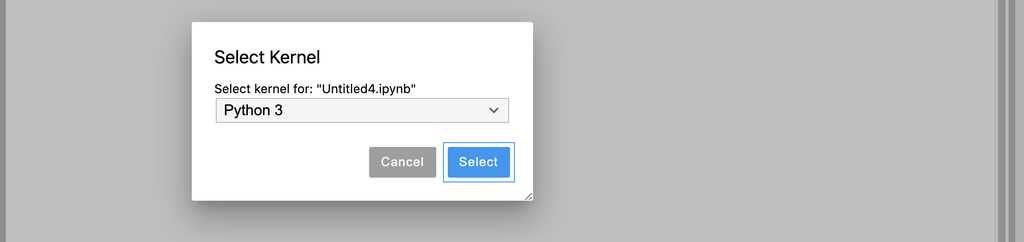

## *9. Open a Python 3 notebook. If you installed supplemental packages, test it by importing one of those packages. For example:*

#### import aiapy

- Run it and it should work 🙂

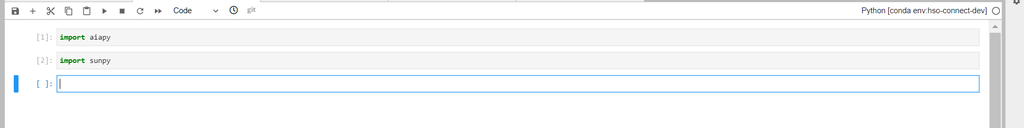

## *If you're unfamiliar with how Jupyter notebooks work, here is a tutorial (it's for Google colab, but most of it works for JupyterHub too):*

https://colab.research.google.com/github/astg606/py_materials/blob/master/jupyter_notebook/jupyter_notebook_introduction.ipynb

Other good python courses developed by the Goddard National Center for Climate Studies (Code 606):

https://astg606.github.io/py_courses/virtual_courses/

## To do list

New item needed: How to update your environment by installing a new package

Also, need to figure out how to point data storage to /efs instead of /home